# Has the Federal Reserve Fulfilled Its Dual Mandate?

Sachi Kapoor

September 2026

Introduction

Congress has given the Federal Reserve a dual mandate of maintaining stable prices and promoting maximum employment. These goals can sometimes conflict. Raising interest rates may help control inflation, but it can also slow economic activity and hiring. Lowering rates may support employment, but it can increase inflation risk.

This analysis examines 25 years of CPI inflation, unemployment, and the federal funds rate to determine whether the Federal Reserve has successfully balanced both objectives. The results suggest partial success, but the Fed has not consistently achieved both goals at the same time.

Story Design

The visualizations are arranged to answer the research question in stages. The first chart compares inflation with the federal funds rate to show how monetary policy responded to changes in prices. The second chart aligns unemployment and interest rates so their timing can be compared without placing variables with different scales on the same axis. The final scorecard summarizes how frequently the inflation and unemployment benchmarks were achieved together.

Line charts were selected for the first two visualizations because all three measures change over time, and the timing of those changes is essential to the analysis. A horizontal bar chart was selected for the scorecard because it makes the four outcomes easy to compare.

## Data Collection

The analysis uses monthly economic data covering the most recent 25-year period. The effective federal funds rate was retrieved from the Federal Reserve Economic Data API. CPI and unemployment data were retrieved from the Bureau of Labor Statistics API.

### Federal Funds Rate

```r
fred_key <- Sys.getenv("FRED_API_KEY")

start_date <- as.Date("2001-09-01")
end_date <- Sys.Date()

fred_request <- request(
  "https://api.stlouisfed.org/fred/series/observations"
) |>
  req_url_query(
    series_id = "FEDFUNDS",
    api_key = fred_key,
    file_type = "json",
    observation_start = start_date,
    observation_end = end_date
  )

fred_response <- fred_request |>
  req_perform() |>
  resp_body_json(simplifyVector = TRUE)

fed_funds <- fred_response$observations |>
  transmute(
    date = as.Date(date),
    fed_funds_rate = na_if(value, ".") |> as.numeric()
  ) |>
  filter(!is.na(fed_funds_rate))

head(fed_funds)
```

```
##         date fed_funds_rate
## 1 2001-09-01           3.07
## 2 2001-10-01           2.49
## 3 2001-11-01           2.09
## 4 2001-12-01           1.82
## 5 2002-01-01           1.73
## 6 2002-02-01           1.74
```

### CPI and Unemployment Rate

The Consumer Price Index and unemployment rate were retrieved directly from the Bureau of Labor Statistics Public Data API. The requests were divided into smaller time periods to comply with the API’s limits. An extra year of CPI data was retrieved so the 12-month inflation rate could be calculated for the complete 25-year analysis period.

```r
bls_series <- c(
  "CUSR0000SA0",
  "LNS14000000"
)

fetch_bls_data <- function(start_year, end_year) {

  bls_response <- request(
    "https://api.bls.gov/publicAPI/v2/timeseries/data/"
  ) |>
    req_body_json(
      list(
        seriesid = bls_series,
        startyear = as.character(start_year),
        endyear = as.character(end_year)
      )
    ) |>
    req_perform() |>
    resp_body_json(simplifyVector = FALSE)

  if (bls_response$status != "REQUEST_SUCCEEDED") {
    stop("The BLS API request was not successful.")
  }

  bind_rows(
    lapply(bls_response$Results$series, function(series) {

      bind_rows(series$data) |>
        transmute(
          series_id = series$seriesID,
          year = as.integer(year),
          month = as.integer(sub("M", "", period)),
          value = as.numeric(value)
        ) |>
        filter(month <= 12)
    })
  )
}

bls_raw <- bind_rows(
  fetch_bls_data(2000, 2009),
  fetch_bls_data(2010, 2019),
  fetch_bls_data(2020, 2026)
)

head(bls_raw)
```

```
## # A tibble: 6 × 4
##   series_id    year month value
##   <chr>       <int> <int> <dbl>
## 1 CUSR0000SA0  2009    12  217.
## 2 CUSR0000SA0  2009    11  217.
## 3 CUSR0000SA0  2009    10  217.
## 4 CUSR0000SA0  2009     9  216.
## 5 CUSR0000SA0  2009     8  215.
## 6 CUSR0000SA0  2009     7  215.
```

### Preparing and Combining the Data

The CPI is published as an index, but an index level does not directly show the inflation rate. I calculated inflation as the percentage change in CPI compared with the same month one year earlier. This makes the measure more useful for evaluating price stability and comparing it with the Federal Reserve’s policy decisions.

```r
bls_clean <- bls_raw |>
  mutate(
    date = make_date(year, month, 1),
    measure = case_when(
      series_id == "CUSR0000SA0" ~ "cpi",
      series_id == "LNS14000000" ~ "unemployment_rate"
    )
  ) |>
  select(date, measure, value) |>
  pivot_wider(
    names_from = measure,
    values_from = value
  ) |>
  complete(
    date = seq.Date(
      from = min(date),
      to = max(date),
      by = "month"
    )
  ) |>
  arrange(date) |>
  mutate(
    inflation_rate = ((cpi / lag(cpi, 12)) - 1) * 100
  )

analysis_end <- min(
  max(bls_clean$date),
  max(fed_funds$date)
)

economic_data <- bls_clean |>
  filter(
    date >= as.Date("2001-09-01"),
    date <= analysis_end
  ) |>
  full_join(fed_funds, by = "date") |>
  filter(
    date >= as.Date("2001-09-01"),
    date <= analysis_end
  ) |>
  arrange(date) |>
  select(
    date,
    cpi,
    inflation_rate,
    unemployment_rate,
    fed_funds_rate
  )

glimpse(economic_data)
```

```
## Rows: 300
## Columns: 5
## $ date              <date> 2001-09-01, 2001-10-01, 2001-11-01, 2001-12-01, 200…
## $ cpi               <dbl> 178.1, 177.6, 177.5, 177.4, 177.7, 178.0, 178.5, 179…
## $ inflation_rate    <dbl> 2.592166, 2.127660, 1.894374, 1.603666, 1.195900, 1.…
## $ unemployment_rate <dbl> 5.0, 5.3, 5.5, 5.7, 5.7, 5.7, 5.7, 5.9, 5.8, 5.8, 5.…
## $ fed_funds_rate    <dbl> 3.07, 2.49, 2.09, 1.82, 1.73, 1.74, 1.73, 1.75, 1.75…
```

```r
validation_results <- tibble(
  first_month = min(economic_data$date),
  last_month = max(economic_data$date),
  months = nrow(economic_data),
  missing_values = sum(is.na(economic_data))
)

validation_results
```

```
## # A tibble: 1 × 4
##   first_month last_month months missing_values
##   <date>      <date>      <int>          <int>
## 1 2001-09-01  2026-08-01    300              3
```

October 2025 CPI and unemployment data are unavailable because BLS data collection was suspended during the 2025 federal government shutdown. I retained the month as missing rather than estimating the values. This avoids presenting imputed values as official observations.

```r
expected_months <- tibble(
  expected_date = seq.Date(
    from = min(economic_data$date),
    to = max(economic_data$date),
    by = "month"
  )
)

missing_months <- expected_months |>
  anti_join(
    economic_data,
    by = c("expected_date" = "date")
  )

missing_months
```

```
## # A tibble: 0 × 1
## # ℹ 1 variable: expected_date <date>
```

## Inflation and the Federal Funds Rate

I selected a line chart because inflation and the federal funds rate are both measured over time. Showing them together makes it easier to compare when inflation changed and when the Federal Reserve responded. This is especially useful because interest-rate decisions usually occur after the Fed reviews inflation and other economic data.

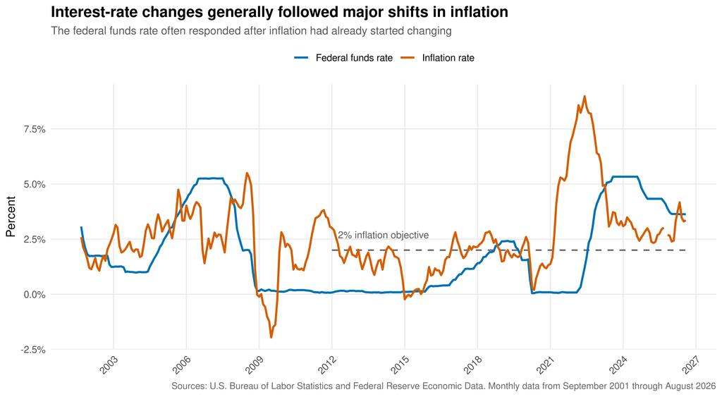

```r
policy_long <- economic_data |>
  select(
    date,
    `Inflation rate` = inflation_rate,
    `Federal funds rate` = fed_funds_rate
  ) |>
  pivot_longer(
    cols = -date,
    names_to = "measure",
    values_to = "rate"
  ) |>
  group_by(measure) |>
  mutate(
    line_segment = cumsum(is.na(rate))
  ) |>
  ungroup()

ggplot(
  policy_long,
  aes(
    x = date,
    y = rate,
    color = measure,
    group = interaction(measure, line_segment)
  )
) +
  annotate(
    "segment",
    x = as.Date("2012-01-01"),
    xend = max(economic_data$date),
    y = 2,
    yend = 2,
    color = "gray40",
    linetype = "dashed",
    linewidth = 0.7
  ) +
  geom_line(
    linewidth = 1,
    na.rm = TRUE
  ) +
  annotate(
    "text",
    x = as.Date("2012-04-01"),
    y = 2.7,
    label = "2% inflation objective",
    color = "gray35",
    size = 3.4,
    hjust = 0
  ) +
  scale_color_manual(
    values = c(
      "Inflation rate" = "#D55E00",
      "Federal funds rate" = "#0072B2"
    )
  ) +
  scale_x_date(
    date_breaks = "3 years",
    date_labels = "%Y"
  ) +
  scale_y_continuous(
    labels = label_number(suffix = "%")
  ) +
  labs(
    title = "Interest-rate changes generally followed major shifts in inflation",
    subtitle = "The federal funds rate often responded after inflation had already started changing",
    x = NULL,
    y = "Percent",
    color = NULL,
    caption = paste(
      "Sources: U.S. Bureau of Labor Statistics and Federal Reserve Economic Data.",
      "Monthly data from",
      format(min(economic_data$date), "%B %Y"),
      "through",
      format(max(economic_data$date), "%B %Y")
    )
  ) +
  theme(
    legend.position = "top",
    axis.text.x = element_text(angle = 45, hjust = 1)
  )
```

The chart shows that the federal funds rate generally changed after inflation had already started moving. The Fed lowered rates during periods of weak inflation and economic stress, especially after the 2008 financial crisis and during the 2020 pandemic. Inflation increased sharply beginning in 2021, while major rate increases began later. Inflation eventually declined as rates remained elevated. This pattern shows that monetary policy works with a delay rather than producing an immediate change in inflation.

## Unemployment and the Federal Funds Rate

I used vertically aligned line charts because they allow the timing of unemployment and interest-rate changes to be compared without placing two measures with very different ranges on the same axis. This makes major events, such as the 2008 recession and the 2020 pandemic, easier to identify while keeping both trends readable.

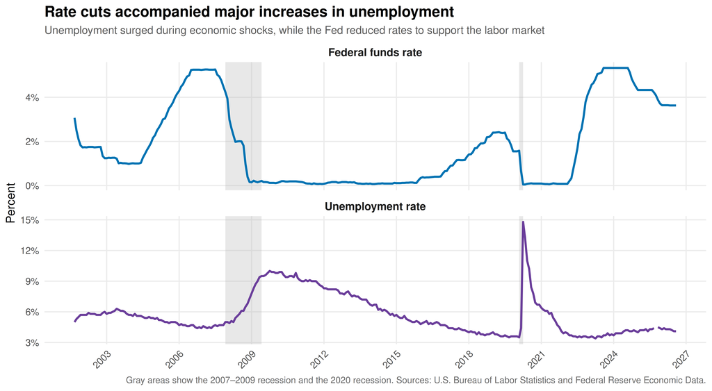

```r
labor_policy_long <- economic_data |>
  select(
    date,
    `Unemployment rate` = unemployment_rate,
    `Federal funds rate` = fed_funds_rate
  ) |>
  pivot_longer(
    cols = -date,
    names_to = "measure",
    values_to = "rate"
  ) |>
  group_by(measure) |>
  mutate(
    line_segment = cumsum(is.na(rate))
  ) |>
  ungroup()

recessions <- tibble(
  start = as.Date(c("2007-12-01", "2020-02-01")),
  end = as.Date(c("2009-06-01", "2020-04-01"))
)

ggplot(
  labor_policy_long,
  aes(
    x = date,
    y = rate,
    color = measure,
    group = interaction(measure, line_segment)
  )
) +
  geom_rect(
    data = recessions,
    aes(
      xmin = start,
      xmax = end,
      ymin = -Inf,
      ymax = Inf
    ),
    inherit.aes = FALSE,
    fill = "gray70",
    alpha = 0.3
  ) +
  geom_line(
    linewidth = 1,
    na.rm = TRUE
  ) +
  facet_wrap(
    ~measure,
    ncol = 1,
    scales = "free_y"
  ) +
  scale_color_manual(
    values = c(
      "Unemployment rate" = "#6A3D9A",
      "Federal funds rate" = "#0072B2"
    )
  ) +
  scale_x_date(
    date_breaks = "3 years",
    date_labels = "%Y"
  ) +
  scale_y_continuous(
    labels = label_number(suffix = "%")
  ) +
  labs(
    title = "Rate cuts accompanied major increases in unemployment",
    subtitle = "Unemployment surged during economic shocks, while the Fed reduced rates to support the labor market",
    x = NULL,
    y = "Percent",
    color = NULL,
    caption = paste(
      "Gray areas show the 2007–2009 recession and the 2020 recession.",
      "Sources: U.S. Bureau of Labor Statistics and Federal Reserve Economic Data."
    )
  ) +
  theme(
    legend.position = "none",
    strip.text = element_text(
      face = "bold",
      size = 11
    ),
    axis.text.x = element_text(
      angle = 45,
      hjust = 1
    )
  )
```

Unemployment increased sharply during the 2007 to 2009 recession and again during the 2020 pandemic. In both cases, the Federal Reserve reduced interest rates as unemployment increased. The rate increases that began after the 2021 inflation surge did not produce a comparable rise in unemployment during the period studied. This suggests that the Fed was able to reduce inflation without creating a major increase in unemployment, although the chart alone cannot prove that Federal Reserve policy caused these outcomes.

## Evaluating Both Parts of the Mandate

To summarize both parts of the mandate, I classified each available month using two descriptive benchmarks. Inflation between 1% and 3% was treated as reasonably close to the Fed’s 2% objective, while unemployment at or below 5% was treated as relatively low. The 5% unemployment level is not an official Federal Reserve target, so this scorecard should be interpreted as a consistent comparison rather than a formal policy test.

I selected a bar chart because it directly shows how frequently the economy met both benchmarks, only one benchmark, or neither benchmark. This provides a clearer answer to the assignment question than another time-series chart.

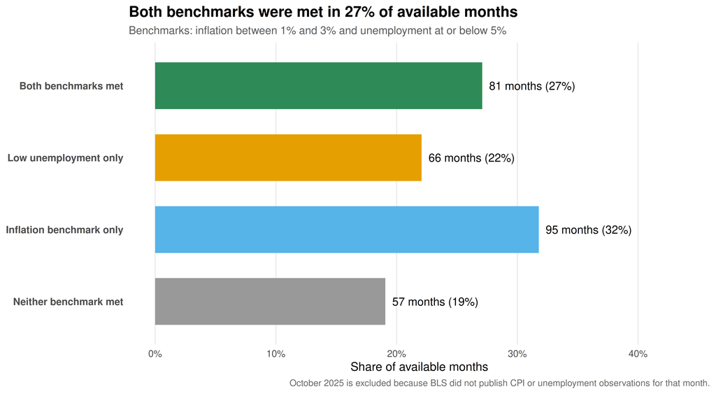

```r
mandate_data <- economic_data |>
  filter(
    !is.na(inflation_rate),
    !is.na(unemployment_rate)
  ) |>
  mutate(
    inflation_near_target =
      inflation_rate >= 1 & inflation_rate <= 3,
    unemployment_low =
      unemployment_rate <= 5,
    outcome = case_when(
      inflation_near_target & unemployment_low ~
        "Both benchmarks met",
      !inflation_near_target & unemployment_low ~
        "Low unemployment only",
      inflation_near_target & !unemployment_low ~
        "Inflation benchmark only",
      TRUE ~
        "Neither benchmark met"
    )
  )
scorecard <- mandate_data |>
  count(outcome) |>
  mutate(
    percent = n / sum(n),
    label = paste0(
      n,
      " months (",
      percent(percent, accuracy = 1),
      ")"
    ),
    outcome = factor(
      outcome,
      levels = c(
        "Neither benchmark met",
        "Inflation benchmark only",
        "Low unemployment only",
        "Both benchmarks met"
      )
    )
  )


both_percent <- scorecard |>
  filter(outcome == "Both benchmarks met") |>
  pull(percent)

ggplot(
  scorecard,
  aes(
    x = percent,
    y = outcome,
    fill = outcome
  )
) +
  geom_col(
    width = 0.65,
    show.legend = FALSE
  ) +
  geom_text(
    aes(label = label),
    hjust = -0.08,
    size = 4
  ) +
  scale_fill_manual(
    values = c(
      "Both benchmarks met" = "#2E8B57",
      "Low unemployment only" = "#E69F00",
      "Inflation benchmark only" = "#56B4E9",
      "Neither benchmark met" = "#999999"
    )
  ) +
  scale_x_continuous(
    labels = percent_format(),
    limits = c(
      0,
      max(scorecard$percent) + 0.12
    )
  ) +
  labs(
    title = paste0(
      "Both benchmarks were met in ",
      percent(both_percent, accuracy = 1),
      " of available months"
    ),
    subtitle = paste(
      "Benchmarks: inflation between 1% and 3%",
      "and unemployment at or below 5%"
    ),
    x = "Share of available months",
    y = NULL,
    caption = paste(
      "October 2025 is excluded because BLS did not publish",
      "CPI or unemployment observations for that month."
    )
  ) +
  theme(
    panel.grid.major.y = element_blank(),
    axis.text.y = element_text(
      face = "bold",
      size = 10
    )
  )
```

Limitations

The assignment requires the Consumer Price Index, but the Federal Reserve’s official 2% inflation objective is measured using the Personal Consumption Expenditures price index. Therefore, the inflation benchmark in this analysis should be considered an approximation.

The Federal Reserve also does not define maximum employment using one permanent unemployment-rate target. The 5% unemployment benchmark used here is a descriptive standard selected for this project rather than an official Federal Reserve target.

These visualizations show relationships and timing, but they do not prove that changes in interest rates caused changes in inflation or unemployment. Monetary policy operates with delays, and the economy is also affected by recessions, fiscal policy, supply disruptions, and events such as the COVID-19 pandemic.

October 2025 values for CPI and unemployment are unavailable because those surveys were not conducted during the federal government shutdown.

Conclusion

Based on this analysis, the Federal Reserve has partially fulfilled its congressional mandate, but it has not consistently achieved both objectives at the same time. Both benchmarks were met during 81 months, or 27% of the available observations.

The charts also show that Federal Reserve policy generally responded after economic conditions had already started changing. Rates were reduced as unemployment increased during the 2007 to 2009 recession and the 2020 pandemic. Rates were later increased after inflation rose sharply beginning in 2021. Inflation subsequently declined while unemployment remained relatively low.

Overall, the evidence does not support a simple yes or no answer. The Federal Reserve has frequently moved policy in a direction consistent with its mandate, but economic shocks and the delayed effects of monetary policy have made it difficult to maintain low inflation and low unemployment continuously.

## Data Sources

- [Bureau of Labor Statistics Public Data API](https://www.bls.gov/developers/)
- [BLS Consumer Price Index](https://www.bls.gov/cpi/)
- [BLS Unemployment Statistics](https://www.bls.gov/cps/)
- [FRED Federal Funds Effective Rate](https://fred.stlouisfed.org/series/FEDFUNDS)
- [Federal Reserve Monetary Policy Goals](https://www.federalreserve.gov/faqs/money_12848.htm)